## Report: act_report

- Create a **250-word-minimum written report** called "act_report.pdf" or "act_report.html" that communicates the insights and displays the visualization(s) produced from your wrangled data. This is to be framed as an external document, like a blog post or magazine article, for example.

# Introduction

I obtained the twitter master dataset from the cleaning process that I had done. This gave me a chance to assess it and look for some insights from the combined twitter master dataset on the WeRate Dogs information. WeRateDogs is a Twitter account that rates people's dogs with a humorous comment about the dog.

The data set had 2175 rows and 36 columns.

# Insights

I imported the modules I required for analysis and generating insights. Below are the questions I got from assessing the dataset:

1. Which source has the highest number of tweets?
2. Which tweets were the users most favorite and what ratings do they have?
3. What are the most common vs rare dog names?

## 1. Which source has the highest number of tweets?

This question was brought about by observing the source column on the data set and observing that there are 4 main categories of the source of the tweets. Therefore, the question arose on which source could have the highest number of tweets. From the figure below, I observed that the source that had the highest number of tweets was from Iphone with 2042 tweets while the lowest is Tweet Deck with 11.

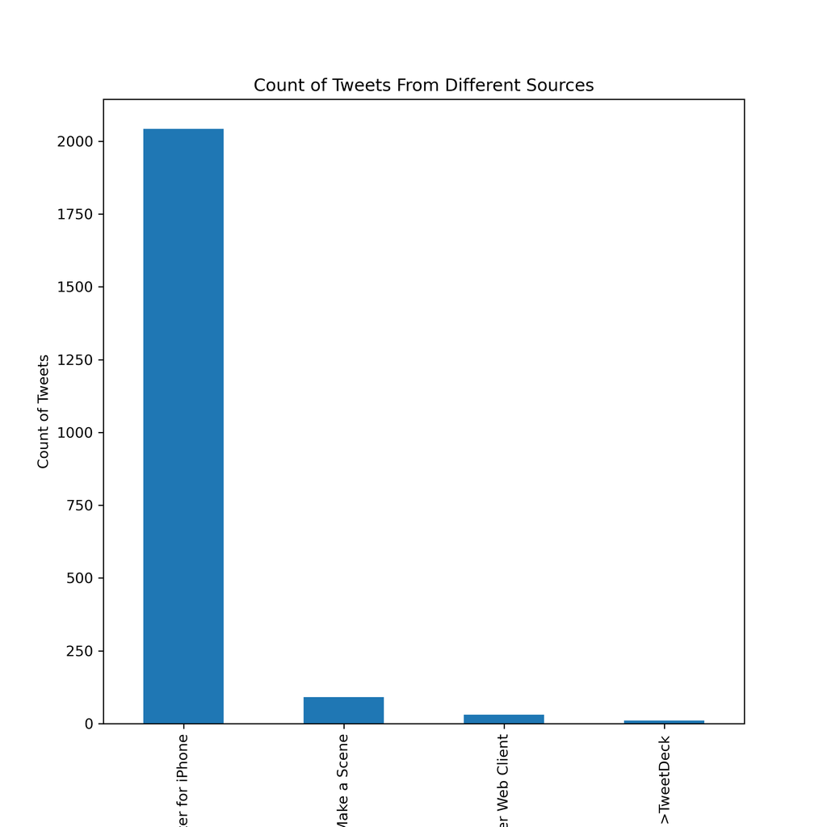

## 2. Which tweets were the users most favorite and what ratings do they have?

I then went on to look at the top 10 favorite tweets of the data set and what was the most common rating among them. From the analysis, I observed that the most favourite tweet had a count of 132810. Among the top 10 most favorite tweets, the most frequent rating was 13.

## 3. What are the most common vs rare dog names?

The final question was about which dog names were versus the rare names. From the analysis of the names, I observed that the most common names were Charlie, Lucy, Cooper, Oliver and Penny were the most common while there were numerous names that were used only once with Charlie and Lucy appearing 11 times.

# Conclusions

1. I observed that the source that had the highest number of tweets was from Iphone with 2042 tweets while the lowest is Tweet Deck with 11.
2. I observed that the most favourite tweet had a count of 132810. Among the top 10 most favorite tweets, the most frequent rating was 13.
3. I observed that the most common names were Charlie, Lucy, Cooper, Oliver and Penny were the most common while there were numerous names that were used only once with Charlie and Lucy appearing 11 times.

# Limitations

I did not perform statistical tests on the data frame provided.

I used the dataset with some missing values.